# Two-Way Repeated Measures ANOVA

Nicholas Wisniewski

May 3, 2016

# 1 Dataset

Let’s make up some frog data like in Drummond and Vowler’s *Analysis of variance: variably complex*. We are interested in seeing if diet has an impact on jumping distance in frogs. Here, frogs were given two different diets, and followed for 3 timepoints. If there is an effect due to the diet, can we tell if is it uniform across time, or if the effects are time dependent?

```r
# Initialization
set.seed(100)
n <- 15
sigma <- 100

# Monte Carlo
t1normal <- rnorm(n, mean=600, sd=sigma)
t1super <- rnorm(n, mean=600, sd=sigma)
t2normal <- rnorm(n, mean=600, sd=sigma)
t2super <- rnorm(n, mean=650, sd=sigma)
t3normal <- rnorm(n, mean=600, sd=sigma)
t3super <- rnorm(n, mean=800, sd=sigma)

# Put together into a dataframe
df <- data.frame(distance = c(t1normal, t1super, t2normal, t2super, t3normal, t3super),
                 time = c(rep("time1", 2*n), rep("time2", 2*n), rep("time3", 2*n)),
                 diet =  rep(c(rep("normal", n), rep("superfood", n)), 3),
                 frog = rep(1:30,3))
head(df,20)
```

```
##    distance  time      diet frog
## 1  549.7808 time1    normal    1
## 2  613.1531 time1    normal    2
## 3  592.1083 time1    normal    3
## 4  688.6785 time1    normal    4
## 5  611.6971 time1    normal    5
## 6  631.8630 time1    normal    6
## 7  541.8209 time1    normal    7
## 8  671.4533 time1    normal    8
## 9  517.4741 time1    normal    9
## 10 564.0138 time1    normal   10
## 11 608.9886 time1    normal   11
## 12 609.6274 time1    normal   12
## 13 579.8366 time1    normal   13
## 14 673.9840 time1    normal   14
## 15 612.3380 time1    normal   15
## 16 597.0683 time1 superfood   16
## 17 561.1146 time1 superfood   17
## 18 651.0856 time1 superfood   18
## 19 508.6186 time1 superfood   19
## 20 831.0297 time1 superfood   20
```

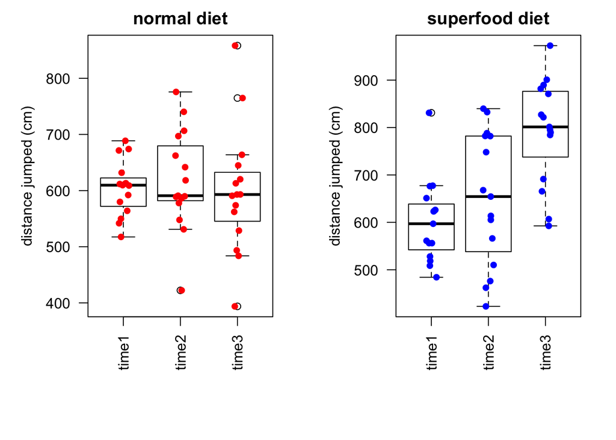

# 2 Repeated-Meausures ANOVA in R

The standard R function for repeated-measures ANOVA is the linear mixed-effect model: lmer().

```r
library(lme4)
library(lmerTest)
model <- lmer(distance ~ diet * time + (1|frog), data=df)
result <- anova(model)
pval.lm <- result$`Pr(>F)`
result
```

```
## Analysis of Variance Table of type III  with  Satterthwaite
## approximation for degrees of freedom
##           Sum Sq Mean Sq NumDF  DenDF F.value    Pr(>F)
## diet      124008  124008     1 84.096 11.8188 0.0009141 ***
## time      133467   66734     2 84.096  6.3602 0.0026779 **
## diet:time 166498   83249     2 84.096  7.9342 0.0006974 ***
## ---
## Signif. codes:  0 '***' 0.001 '**' 0.01 '*' 0.05 '.' 0.1 ' ' 1
```

We see that the time interaction is statistically significant. We should therefore be careful about interpreting the main effects (as seen in the boxplots of the marginals); we can tell from the interaction plot below that they only show up due to the interaction term.

Let’s look at the interaction plot. We notice that the timepoints look the same while on a normal diet, but the effect of the superfood diet grows over time; there is an interaction.

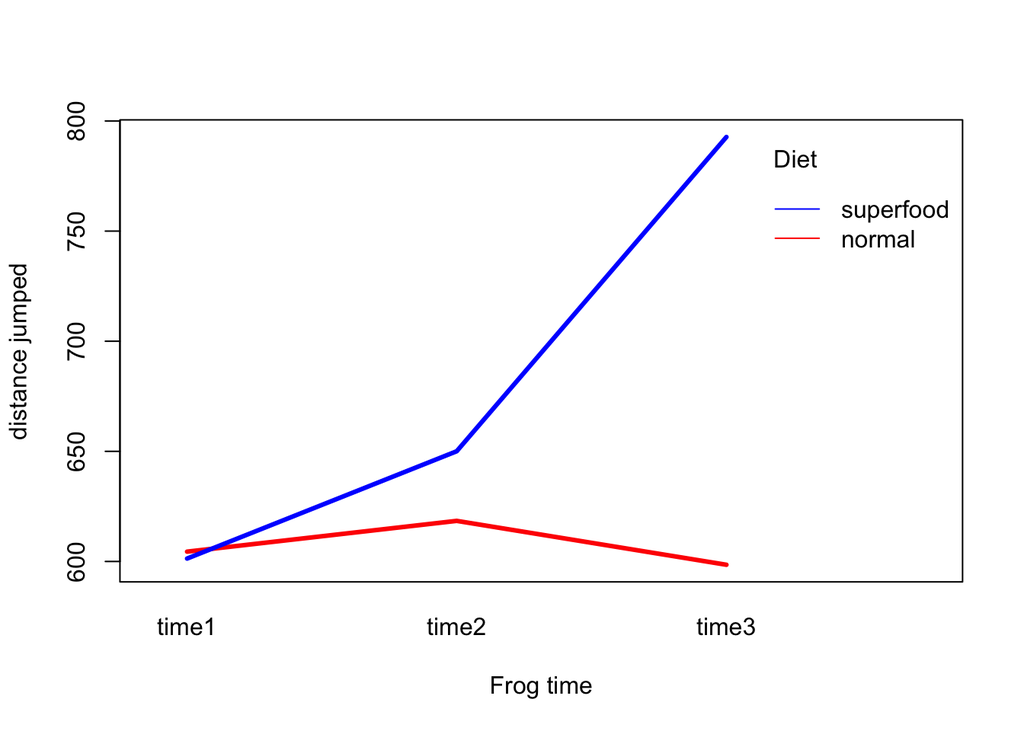

Let’s look at the marginal distributions, which represent the main effects of time and diet. Notice how the marginals can be misleading. The differences between time only appear with the superfood diet, so it is misleading to say that some time can jump farther in general (left). And the gain distance due to superfood (right) is not experienced by all timepoints; timepoint 1 is unaffected by superfood.

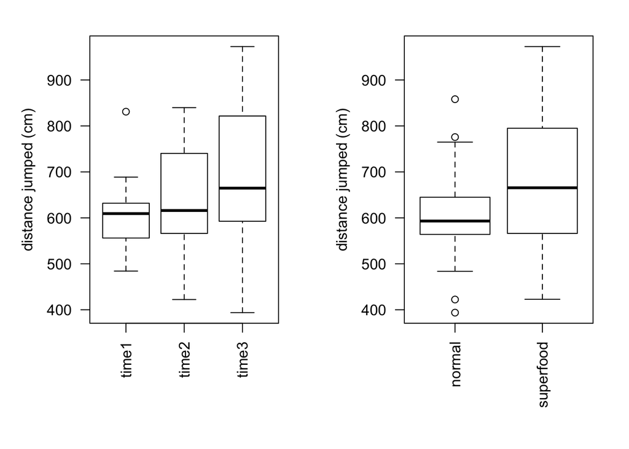

## 2.1 One-Way ANOVA: Interpreting the interaction

The significant interaction term suggests that we should not trust the main effects from the repeated measures ANOVA. If diet affects different times differently, we should look at the effects in each time slice separately. We can do this by investigating the simple main effects found by using 1-way ANOVA on the subgroups.

First, we look for differences between diets at each time separately. So these are not repeated-measures since they’re at a single time slice.

```r
df.time <- split(df, df$time)

anova(lm(distance ~ diet, data=df.time$time1)) # time 1
```

```
## Analysis of Variance Table
##
## Response: distance
##           Df Sum Sq Mean Sq F value Pr(>F)
## diet       1     74    73.8  0.0145 0.9051
## Residuals 28 142821  5100.7
```

```r
anova(lm(distance ~ diet, data=df.time$time2)) # time 2
```

```
## Analysis of Variance Table
##
## Response: distance
##           Df Sum Sq Mean Sq F value Pr(>F)
## diet       1   7502  7502.3  0.5352 0.4705
## Residuals 28 392521 14018.6
```

```r
anova(lm(distance ~ diet, data=df.time$time3)) # time 3
```

```
## Analysis of Variance Table
##
## Response: distance
##           Df Sum Sq Mean Sq F value    Pr(>F)
## diet       1 282930  282930  22.895 4.995e-05 ***
## Residuals 28 346023   12358
## ---
## Signif. codes:  0 '***' 0.001 '**' 0.01 '*' 0.05 '.' 0.1 ' ' 1
```

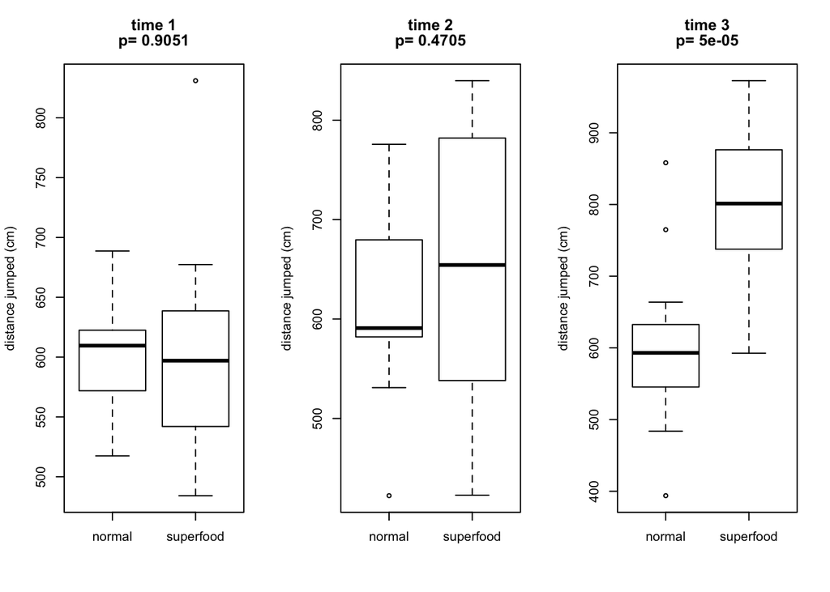

The diet has a statistically significant effect at time 3, but not the others. If there were several different diets, we would be interested in looking next at post-hoc t-tests. But there are only two diets in this experiment, so the 1-way ANOVA’s we just did were equivalent to t-tests.

Next, we look for differences between time in each diet group. These are repeated measures.

```r
df.diet <- split(df, df$diet)

anova(lmer(distance ~ time + (1|frog), data=df.diet$normal)) #normal
```

```
## Analysis of Variance Table of type III  with  Satterthwaite
## approximation for degrees of freedom
##      Sum Sq Mean Sq NumDF  DenDF F.value Pr(>F)
## time 3144.7  1572.4     2 28.009 0.24707 0.7828
```

```r
anova(lmer(distance ~ time + (1|frog), data=df.diet$superfood)) #superfood
```

```
## Analysis of Variance Table of type III  with  Satterthwaite
## approximation for degrees of freedom
##      Sum Sq Mean Sq NumDF  DenDF F.value    Pr(>F)
## time 296820  148410     2 42.036  11.138 0.0001314 ***
## ---
## Signif. codes:  0 '***' 0.001 '**' 0.01 '*' 0.05 '.' 0.1 ' ' 1
```

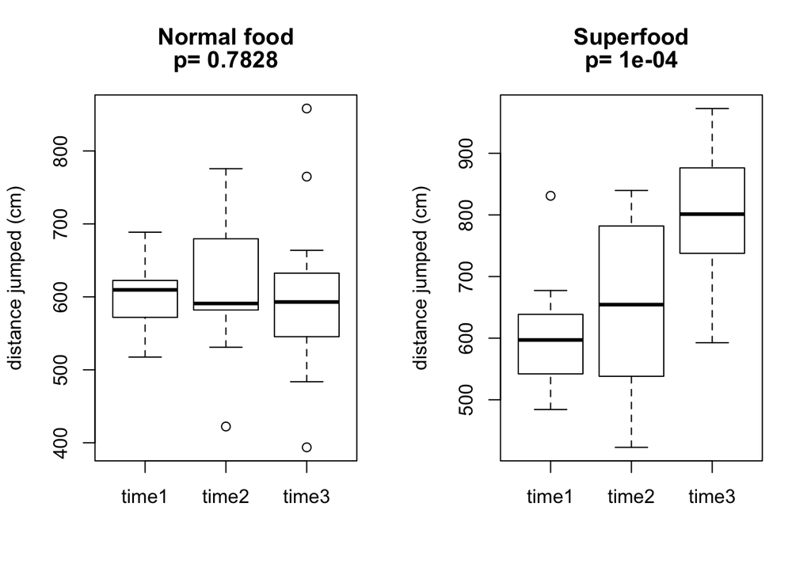

Frogs on the superfood diet have significant differences across time. But there is no difference between timepoints on the normal diet.

This leads to the question: what are the differences between timepoints in the superfood diet group? We already can tell that timepoint 3 jumps farther than the earler timepoints. But to quantify this, we will do pairwise paired t-tests between each time.

### 2.1.1 Pairwise tests

We do the posthoc tests on the superfood diets:

```r
pairwise.t.test(df.diet$superfood$distance, df.diet$superfood$time, paired=T, p.adjust="bonferroni") # Super diet
```

```
##
##  Pairwise comparisons using paired t tests
##
## data:  df.diet$superfood$distance and df.diet$superfood$time
##
##       time1  time2
## time2 0.9025 -
## time3 0.0038 0.0173
##
## P value adjustment method: bonferroni
```

The result shows that timepoint 3 is statistically significantly different than the rest, while time1 and time2 are not statistically significantly different.

## 2.2 Verifying assumptions

We could check the homogeneity of variance assumption using a test. If the data is normally distributed, the Bartlett test is the most powerful test to use. However, it is sensitive to data which is not non-normally distribution; it is more likely to return a “false positive” when the data is non-normal. There is also Levene’s test, which is more robust to departures from normality than Bartlett’s test. And finally, there is the Fligner-Killeen test, which is a non-parametric test that is very robust against departures from normality.

```r
bartlett.test(distance ~ interaction(diet,time), data=df)
```

```
##
##  Bartlett test of homogeneity of variances
##
## data:  distance by interaction(diet, time)
## Bartlett's K-squared = 14.352, df = 5, p-value = 0.01352
```

```r
fligner.test(distance ~ interaction(diet,time), data=df)
```

```
##
##  Fligner-Killeen test of homogeneity of variances
##
## data:  distance by interaction(diet, time)
## Fligner-Killeen:med chi-squared = 11.064, df = 5, p-value =
## 0.05013
```

```r
library(car)
leveneTest(distance ~ interaction(diet,time), data=df)
```

```
## Levene's Test for Homogeneity of Variance (center = median)
##       Df F value  Pr(>F)
## group  5  2.6536 0.02815 *
##       84
## ---
## Signif. codes:  0 '***' 0.001 '**' 0.01 '*' 0.05 '.' 0.1 ' ' 1
```

But there are also some plots to look at. The residual plot shows if there is a pattern in the residuals. It should indicate homoscedasticity. We can also look at what’s happening for each frog individually over time.

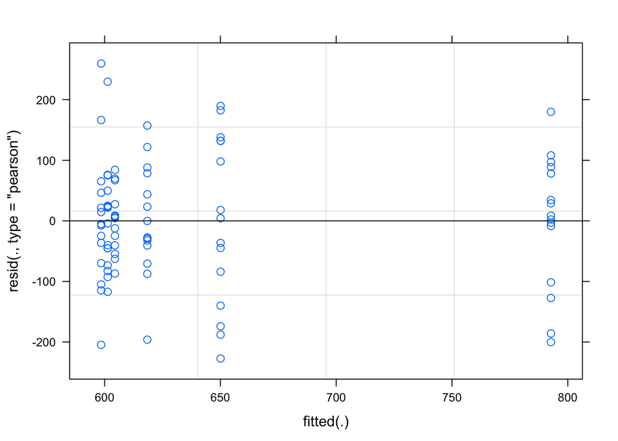

We can also look at the results for each individual frog, and the model predictions for each frog.

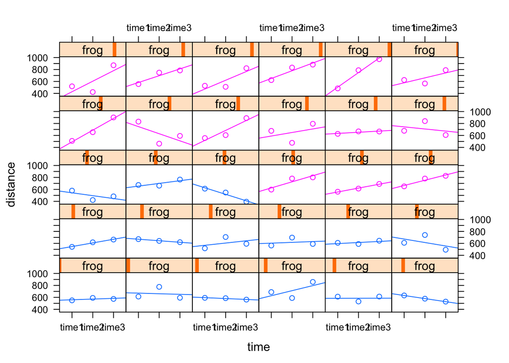

```r
library(lattice)
lattice::xyplot(distance~time| frog, groups=diet, data=df, type=c('p','r'), auto.key=F)
```

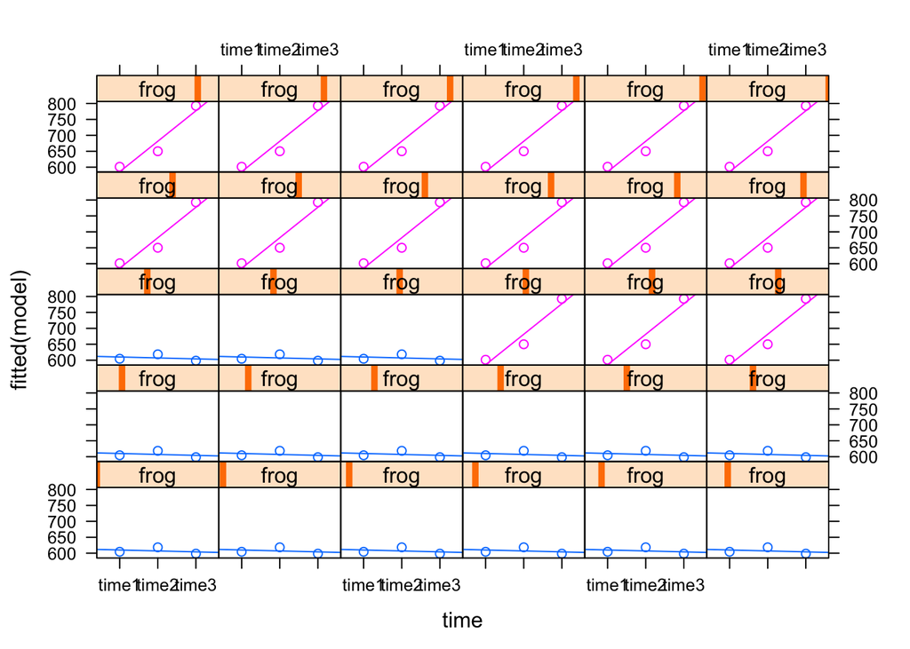

```r
lattice::xyplot(fitted(model)~time| frog, groups=diet, data=df, type=c('p','r'), auto.key=F)
```

# 3 Nonparametric tests

No good R package exists. We can transform to ranks. Note that this is not recommended, as Monte Carlo studies by Sawilowsky show problems.

```r
model <-  lmer(rank(distance) ~ diet * time + (1|frog), data=df)
result <- anova(model)
pval.rank <- result$`Pr(>F)`
result
```

```
## Analysis of Variance Table of type III  with  Satterthwaite
## approximation for degrees of freedom
##           Sum Sq Mean Sq NumDF  DenDF F.value   Pr(>F)
## diet      4508.5  4508.5     1 84.003  8.4042 0.004775 **
## time      4530.9  2265.4     2 84.003  4.2229 0.017884 *
## diet:time 6640.3  3320.1     2 84.003  6.1890 0.003109 **
## ---
## Signif. codes:  0 '***' 0.001 '**' 0.01 '*' 0.05 '.' 0.1 ' ' 1
```

Again, we see an interaction.

## 3.1 One-Way ANOVA: Interpreting the interaction

We can do the one-way tests for each subroup. We begin with looking at diet in each time separately. Since they are time slices, this is not a repeated-measures test.

```r
kruskal.test(distance~diet, data=df.time$time1) # diet at t1
```

```
##
##  Kruskal-Wallis rank sum test
##
## data:  distance by diet
## Kruskal-Wallis chi-squared = 0.096774, df = 1, p-value = 0.7557
```

```r
kruskal.test(distance~diet, data=df.time$time2) # diet at t2
```

```
##
##  Kruskal-Wallis rank sum test
##
## data:  distance by diet
## Kruskal-Wallis chi-squared = 0.72301, df = 1, p-value = 0.3952
```

```r
kruskal.test(distance~diet, data=df.time$time3) # diet at t3
```

```
##
##  Kruskal-Wallis rank sum test
##
## data:  distance by diet
## Kruskal-Wallis chi-squared = 13.475, df = 1, p-value = 0.0002418
```

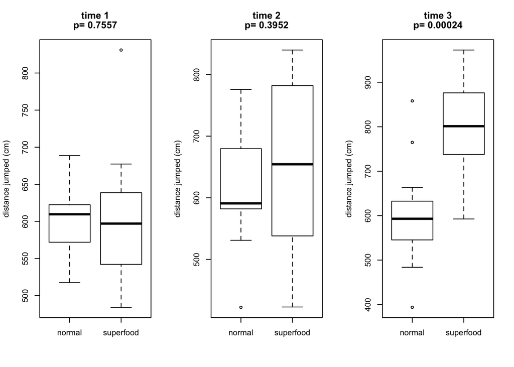

We see that there is a statistically significant difference in treefrogs between the mean distance jumped on normal diets and on superfood. This difference does not appear in the other frogs.

Next, we look at differences between time within each diet subgroup. This is repeated-measures, and is done using the Friedman test.

```r
friedman.test(distance~time|frog, data=df.diet$normal) # time differences in normal diet subgroup
```

```
##
##  Friedman rank sum test
##
## data:  distance and time and frog
## Friedman chi-squared = 0.13333, df = 2, p-value = 0.9355
```

```r
friedman.test(distance~time|frog, data=df.diet$superfood) # time differences in superfood diet subgroup
```

```
##
##  Friedman rank sum test
##
## data:  distance and time and frog
## Friedman chi-squared = 12.933, df = 2, p-value = 0.001554
```

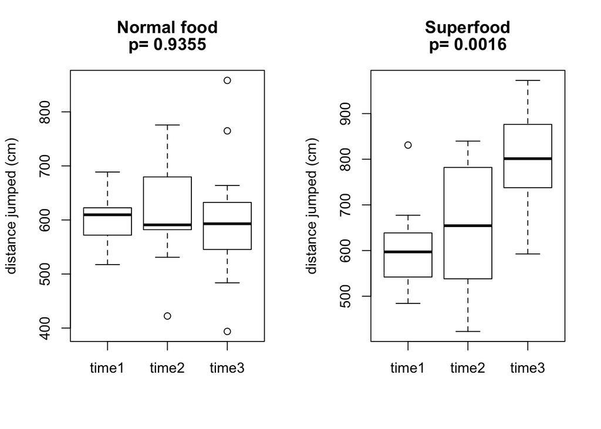

We see that there is a statistically significant difference between timepoints in the superfood subgroup. To quantify these differences, we will use nonparametric post-hoc tests.

### 3.1.1 Pairwise tests

For post-hoc testing, we can use pairwise paired Mann-Whitney U tests. We look for differences between time in the superfood group.

```r
pairwise.wilcox.test(df.diet$superfood$distance, df.diet$superfood$time, paired=T, p.adjust="bonferroni") # Superfood
```

```
##
##  Pairwise comparisons using Wilcoxon signed rank test
##
## data:  df.diet$superfood$distance and df.diet$superfood$time
##
##       time1 time2
## time2 0.76  -
## time3 0.01  0.01
##
## P value adjustment method: bonferroni
```

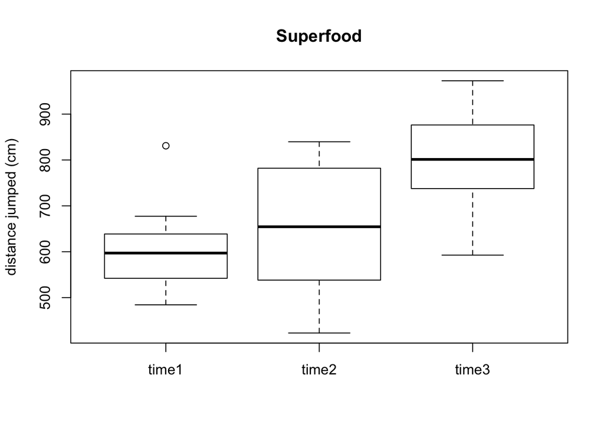

We see that timepoint 3 is different from the rest.

# 4 Bootstrap tests

```r
# Define functions to compute the Sum of Squares, and Sum of Abs
ssq <- function(x) sum(x^2)
sab <- function(x) sum(abs(x))

# Compute the SS_subject term
SSsubject <- function( X, subject, f2, center=mean, agg=ssq){
    long <- data.frame(cbind(subject, f2, X))
    wide <- reshape(long, v.names="X", idvar = "subject", timevar = "f2",direction = "wide")
    k <- ncol(wide[,-1])
    subjectMeans <- rowMeans(wide[,-1])
    SSsubject <- k*agg(subjectMeans - center(X))
    return( SSsubject)
}

# A more general function to compute the F-statistic
Fstat.2wayRM <- function( X, f1, f2, subject, center=mean, agg=ssq, rank=FALSE) {
    if (rank==FALSE){Y = X} else{Y = rank(-X)}
    mu <- center(Y)  #Grand Mean
    groupMeans.f1 <- ave( Y, f1, FUN=center ) #Pool f1
    groupMeans.f2 <- ave( Y, f2, FUN=center ) #Pool f2
    groupMeans.int <- ave( Y, f1, f2, FUN=center ) #Cell means
    SSB.f1 <- agg(groupMeans.f1 - mu)
    SSB.f2 <- agg(groupMeans.f2 - mu)
    SSB.int <- agg( groupMeans.int - (groupMeans.f1 + groupMeans.f2 - mu) )
    SSW <- agg(Y - groupMeans.int)
    SSsub <- SSsubject(Y, subject, f2, center=center, agg=agg)
    SSe <- SSW - SSsub
    return( c(f1=SSB.f1 , f2=SSB.f2, int=SSB.int) /  SSe )
}

# Recenter each of the timepoints before resampling
center.time <- function( X, f2, center=mean){
    timeMeans <- ave( X, f2, FUN=center )
    return(X - timeMeans)
}

# Convert wide dataframe to long
wideToLong <- function(wide, timecols, timenames){
    long <- reshape(wide, varying = timecols, v.names = "X", timevar = "f2", times = timenames, direction = "long")
    return(long)
}
```

## 4.1 F-statistic using L2-norm (sum of squared deviations around the mean)

Now let’s implement the bootstrap using the mean and sum of squares:

```r
X <- df$distance
f1 <- df$diet
f2 <- df$time  # f2 must be time in order for the code to work
subject <- df$frog
deals <- 10000

# initialize some new dataframes
Y <- center.time(X, f2, center=mean) # recenter timepoints
long <- data.frame(subject, f1, f2, Y)  # put into a long dataframe
wide <- reshape(long, v.names="Y", timevar="f2", idvar="subject", direction="wide") # convert to short dataframe to resample subjects

# initialize bootstrap holders
boot.wide <- wide # initialize
bootF <- matrix(NA, nrow=deals, ncol=3) # preallocate
indices <- 1:nrow(wide) # initialize

# Bootstrap
F0 <- Fstat.2wayRM(X, f1, f2, subject, center=mean, agg=ssq, rank=F)
for(i in 1:deals){
    boot.i <- sample(indices, replace=T)  # resample subjects
    boot.wide[,3:5] <- wide[boot.i,3:5]  # get resampled data, which keeps the temporal samples linked
    boot.long <- wideToLong(boot.wide, names(boot.wide)[3:5])  # convert to long format
    bootF[i,] <- Fstat.2wayRM(boot.long$X, boot.long$f1, boot.long$f2, boot.long$subject, center=mean, agg=ssq, rank=F)
}
pval.L2 <- colSums(sweep(bootF, 2, F0,"-") > 0) / deals
```

Take a look at the null distribution for the F statistic:

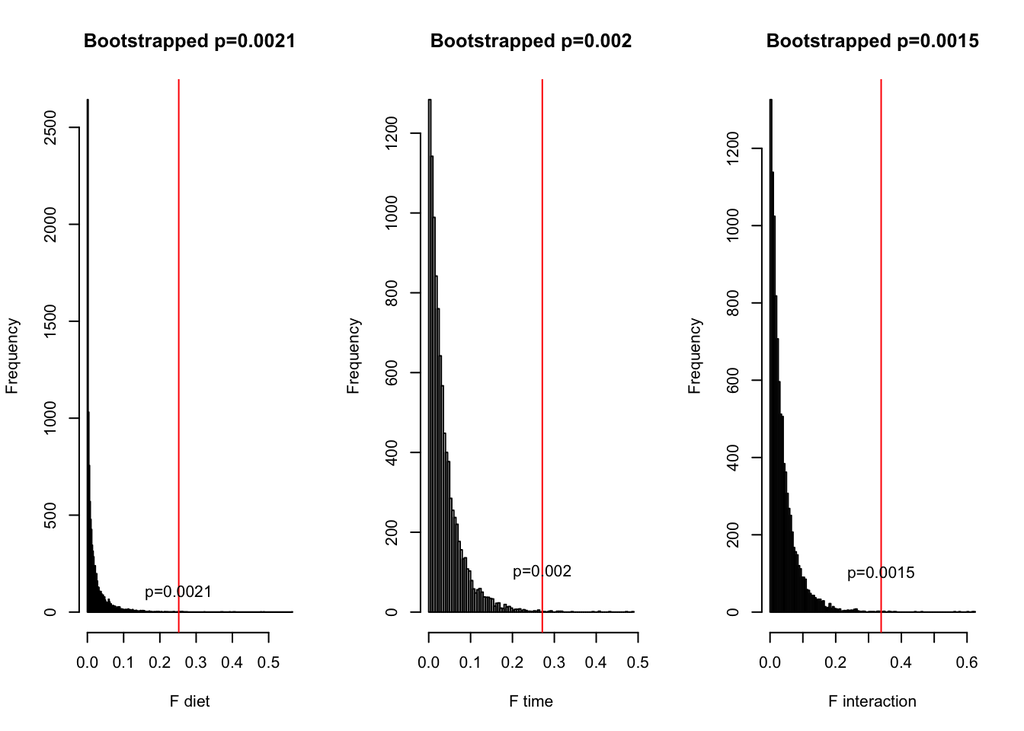

## 4.2 F-statistic using L1-norm (sum of absolute deviations around the mean)

Now let’s implement the bootstrap using the mean and sum of absolute deviations:

```r
F0 <- Fstat.2wayRM(X, f1, f2, subject, center=mean, agg=sab, rank=F)
for(i in 1:deals){
    boot.i <- sample(indices, replace=T)  # resample subjects
    boot.wide[,3:5] <- wide[boot.i,3:5]  # get resampled data, which keeps the temporal samples linked
    boot.long <- wideToLong(boot.wide, names(boot.wide)[3:5])  # convert to long format
    bootF[i,] <- Fstat.2wayRM(boot.long$X, boot.long$f1, boot.long$f2, boot.long$subject, center=mean, agg=sab, rank=F)
}
pval.L1 <- colSums(sweep(bootF, 2, F0,"-") > 0) / deals
```

Take a look at the null distribution for the F statistic. We get a very similar p-value:

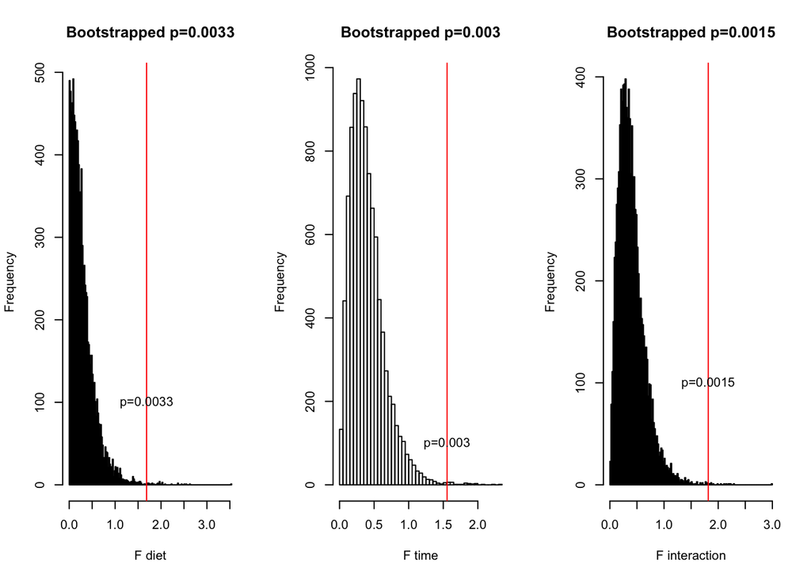

## 4.3 Rank test

Now let’s implement the bootstrap using ranks:

```r
F0 <- Fstat.2wayRM(X, f1, f2, subject, center=mean, agg=ssq, rank=T)
for(i in 1:deals){
    boot.i <- sample(indices, replace=T)  # resample subjects
    boot.wide[,3:5] <- wide[boot.i,3:5]  # get resampled data, which keeps the temporal samples linked
    boot.long <- wideToLong(boot.wide, names(boot.wide)[3:5])  # convert to long format
    bootF[i,] <- Fstat.2wayRM(boot.long$X, boot.long$f1, boot.long$f2, boot.long$subject, center=mean, agg=ssq, rank=T)
}
pval.rankboot <- colSums(sweep(bootF, 2, F0,"-") > 0) / deals
```

Take a look at the null distribution for the F statistic. We get a very similar p-value:

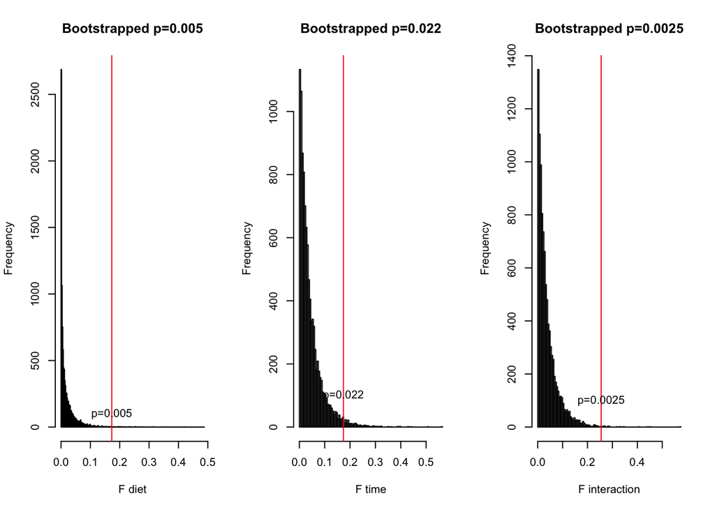

# 5 P-value comparison

|  | diet | time | interaction |
| --- | --- | --- | --- |
| built-in ANOVA | 0.0009 | 0.0027 | 0.0007 |
| bootstrap with L1-norm | 0.0033 | 0.0030 | 0.0015 |
| bootstrap with L2-norm | 0.0021 | 0.0020 | 0.0015 |
| rank | 0.0048 | 0.0179 | 0.0031 |
| bootstrap rank | 0.0050 | 0.0220 | 0.0025 |